# Chap 12 Stat Rethink

Anabelle Laurent

8/21/2020

When the observed variance exceed *Np(1-p)* with *Np* beign the expected value of a binomial, then we have overdispersion. It implies that omitted variable(s) is producing additional dispersion to the observed counts.

Question 1: is the omitted variable the only reason to produce overdipersion? What about biological variation, error of measurement?

**Beta-binomial** estimates the distribution of probabilities of success instead of a single probability of success.

**Cumulative probability** is the probability of a value or *any smaller value*.

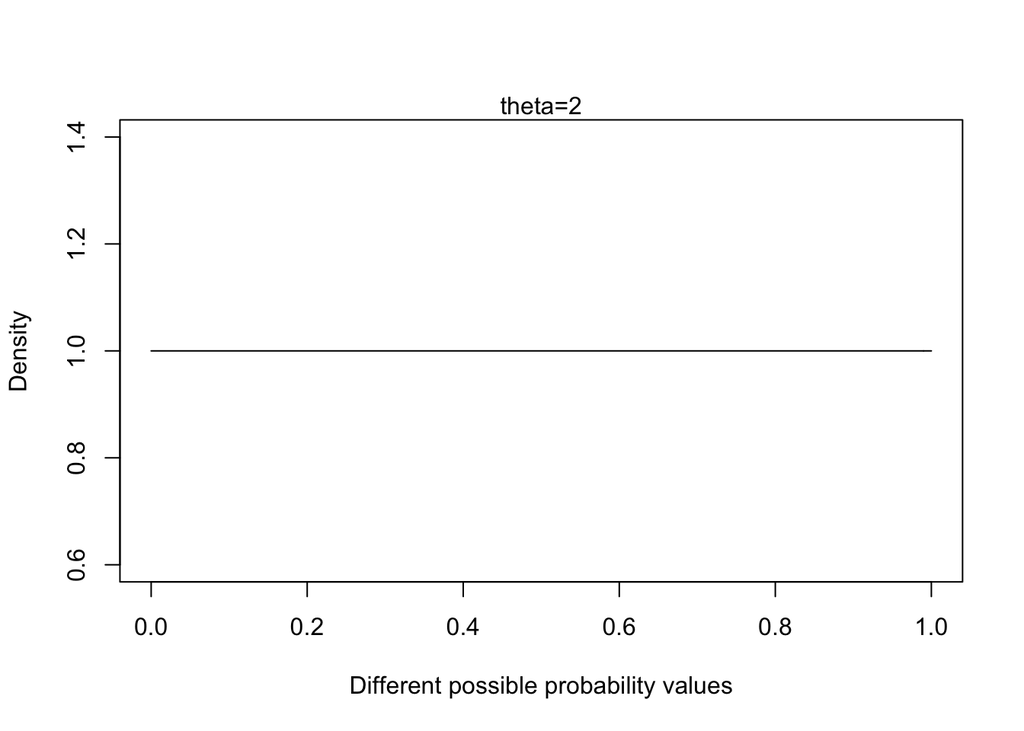

```r
pbar <- 0.5
theta <- 2
curve( dbeta2(x,pbar,theta) , from=0 , to=1 ,
    xlab="Different possible probability values" , ylab="Density" )
mtext("theta=2")
```

When theta (shape parameter that describes how spread out is the distribution) =2, every proba from 0 to 1 is equally likely.

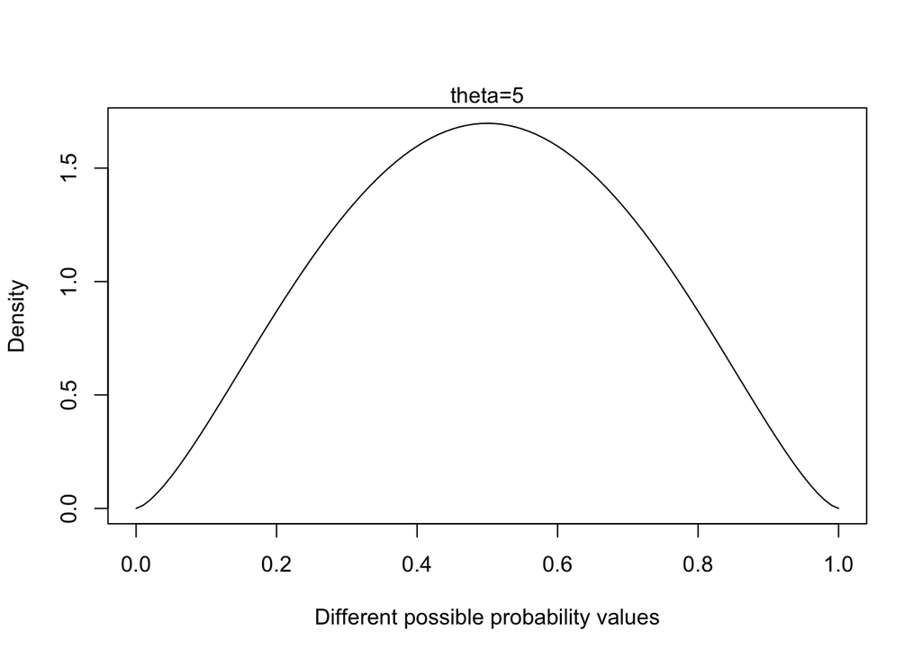

```r
pbar <- 0.5
theta <- 5
curve( dbeta2(x,pbar,theta) , from=0 , to=1 ,
    xlab="Different possible probability values" , ylab="Density" )
mtext("theta=5")
```

When theta >2, the distribution of proba grows more concentrated.

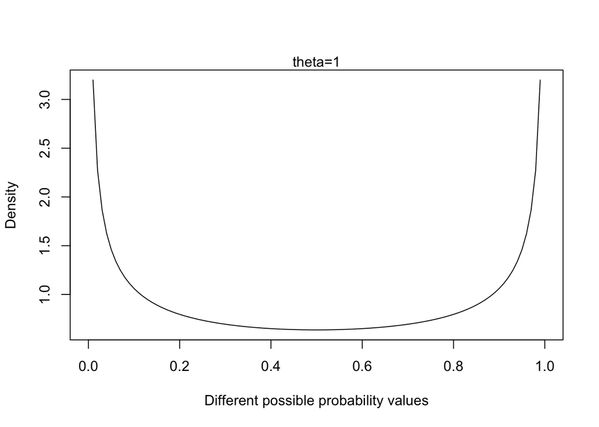

```r
pbar <- 0.5
theta <- 1
curve( dbeta2(x,pbar,theta) , from=0 , to=1 ,
    xlab="Different possible probability values" , ylab="Density" )
mtext("theta=1")
```

Question 2: Why binomial does not return a distribution? With the chain we can get a distribution of the outcome

**Negative-binomial or gamma-Poisson** assumes that each Poisson count has its own rate. As Gamma-poisson expected more variation around the mean, a high influential data in Poisson becomes less influential with Gamma-Poisson.

## E4

Overdispersion: you go to a shelter and you ask dogs to seat (n=10) (if the dog seats=success). As dogs in a shelter varies in age, sex, breed, history you can expect overdispersion.  
Underdispersion: you go to a dog breeder already educating his dogs for adoption, you can expect a success most of the time.

## M1 & M2

```r
rate<-c(rep(1,12),rep(2,36),rep(3,7),rep(4,41))

# discrete proportion of each response value
pr_k <- table( rate ) / 96

# cumsum converts to cumulative proportions
cum_pr_k <- cumsum( pr_k )

logit <- function(x) log(x / (1 - x)) # convenience function
logit(cum_pr_k)
```

```
##          1          2          3          4
## -1.9459101  0.0000000  0.2937611        Inf
```

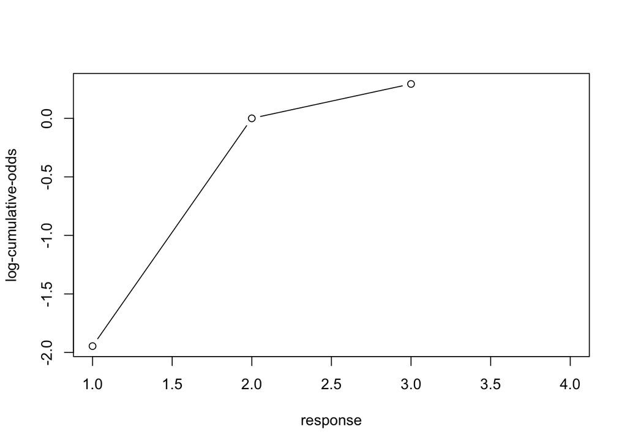

```r
plot(1:4,logit(cum_pr_k),type="b",xlab="response",ylab="log-cumulative-odds")
```

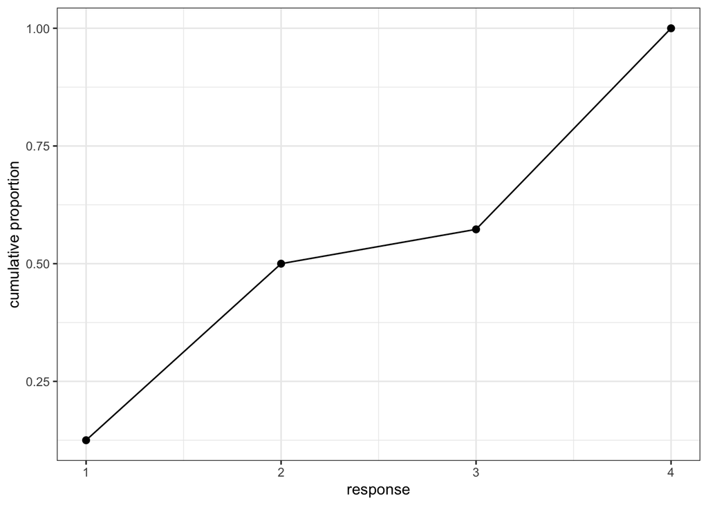

```r
dplot<-data.frame(rate=c(1:4),cum_pr_k)

dplot %>% ggplot() +
  geom_line(aes(x=c(1,2,3,4),y=cum_pr_k)) +
  geom_point(aes(x=c(1,2,3,4),y=cum_pr_k),size=2) +
  xlab("response") +
  ylab("cumulative proportion")
```

## H1 🌪

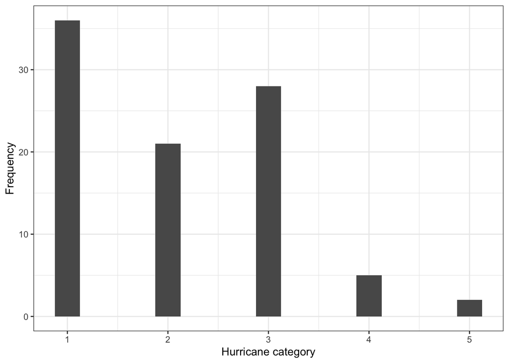

```r
data(Hurricanes)
d <- Hurricanes

d %>%
  ggplot(aes(x = category)) +
  geom_histogram(binwidth = 1/4, size = 0) +
  xlab("Hurricane category") +
  ylab("Frequency")
```

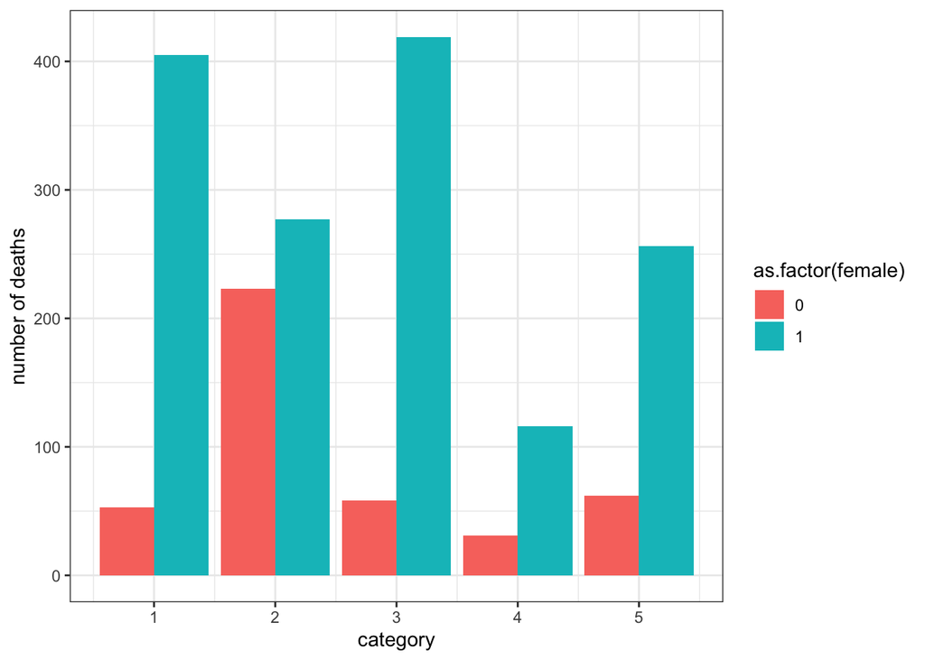

```r
d2<- d %>% group_by(category,female) %>% summarise (n=sum(deaths))
ggplot(d2,aes(category,n,fill=as.factor(female)))+
  geom_bar(stat="identity",position='dodge') +
  ylab("number of deaths")
```

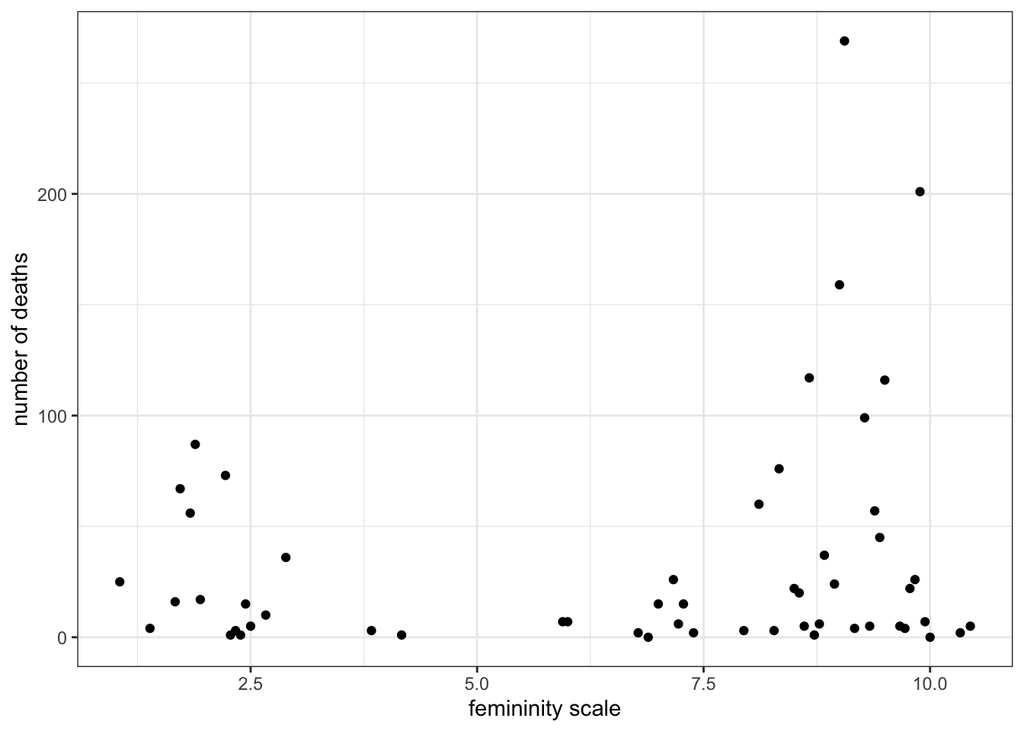

```r
d3<- d %>% group_by(femininity) %>% summarise (n=sum(deaths))
ggplot(d3,aes(x=femininity,y=n))+ geom_point() +
   ylab("number of deaths") +
  xlab("femininity scale")
```

```r
dat <- list(
    D = d$deaths ,
    F = d$femininity)

# intercept only
m1<- ulam(
    alist(
        D ~ dpois( lambda ),
        log(lambda) <- a,
        a ~ dnorm( 0 , 10)
    ), data=dat , chains=4 , log_lik=TRUE )


#  model with predictor
m2 <- ulam(
    alist(
        D ~ dpois( lambda ),
        log(lambda) <- a + b*F,
        a~ dnorm( 0 , 10 ),
        b~ dnorm( 0 , 5 )
    ), data=dat , chains=4 , log_lik=TRUE )
precis(m2, depth = 2)
```

[output not shown]

```r
precis(m1, depth = 2)
```

```
##       mean         sd     5.5%   94.5%    n_eff    Rhat4
## a 3.026761 0.02193792 2.989979 3.06081 906.1097 1.006407
```

```r
precis(m2, depth = 2)
```

```
##         mean         sd       5.5%      94.5%    n_eff    Rhat4
## a 2.49458350 0.06325424 2.38376140 2.59010748 410.7782 1.006582
## b 0.07464815 0.00802071 0.06257127 0.08831616 432.8024 1.005542
```

```r
compare( m1 , m2 , func=PSIS )
```

```
##        PSIS        SE    dPSIS     dSE     pPSIS       weight
## m2 4406.892  996.4751  0.00000      NA 127.08814 0.9995778075
## m1 4422.431 1066.3963 15.53925 137.991  62.73004 0.0004221925
```

## H2

```r
m3<- ulam(
    alist(
        D ~ dgampois( lambda , phi ),
        log(lambda) <- a + b*F,
        a ~ dnorm(0,10),
        b ~ dnorm(0,5),
        phi ~ dexp(1)
    ), data=dat , chains=4 , log_lik=TRUE )
```

```r
precis(m3,depth = 2)
```

```
##           mean         sd         5.5%     94.5%    n_eff    Rhat4
## a   2.55362870 0.36405770  2.004677850 3.1540381 767.1060 1.007936
## b   0.06911276 0.04826961 -0.006811208 0.1438008 725.9933 1.006167
## phi 0.45120173 0.06150711  0.358083591 0.5490459 986.2219 1.004202
```

```r
compare(m2,m3,func=PSIS)
```

```
##         PSIS        SE    dPSIS      dSE      pPSIS weight
## m3  709.5387  32.13924    0.000       NA   3.580421      1
## m2 4406.8922 996.47511 3697.353 974.9074 127.088144      0
```